# Notes on Interest Rate Simulation

William G. Foote

11/16/2018

## The rates have it

Suppose we are thinking about entering into a 10 year swap: the paying leg is in EUR and the receiving leg in JPY. There is one transaction at the the end of 10 years. Each leg is computed using high quality market rates.

Here are [JPY 10-year](https://fred.stlouisfed.org/series/IRLTLT01JPM156N) and [EUR 10-year](https://fred.stlouisfed.org/series/IRLTLT01EZM156N) high quality bond rates.

```r
data_all <- read.csv("data/jpy-eur-10-rates.csv", stringsAsFactors = FALSE)
r_JPY <-  data_all[1:276,2]
r_EUR <- data_all[1:276,3]
n <-  length(r_JPY)
r_JPY_1 <-  stats::lag(r_JPY)[-n]
delta_r_JPY <-  diff(r_JPY)
n <-  length(r_EUR)
r_EUR_1 <-  stats::lag(r_EUR)[-n]
delta_r_EUR <-  diff(r_EUR)
n <-  length(r_EUR_1)
t <-  seq(from=1989,to =2018,length=n)
#r1_df <- data.frame(lag_r1 = lag_r1, delta_r1 = delta_r1, t = t)
#ggplot(r1_df, aes(x = t, y = lag_r1)) + geom_line() + geom_line(aes(x = t, y = delta_r1))
#  CKLS (Chan, Karolyi, Longstaff, Sanders)
```

Let’s look at this data.

1. Are there trends in each market? Simple line plots of the time series of rates will help us define trends and whether the data is stationary, cycled, discontinuous. Autocorrelations will tell us something about the reliance of current on past rates.
2. How do rates change? Difference plots will help us see if movements in rates revert to a perhaps moving target of returns, and how fast.
3. Is there any pattern in the volatility? Absolute values in differences, or even squares of differences will show us some ideas about how constant, or not is volatility.

For each of these we will eventually bootstrap sampled means, standard deviations, skewness, and kurtosis to get a further handle on the character of the data.

### Trends

Are there trends in each market? Simple line plots of the time series of rates will help us define trends and whether the data is stationary, cycled, discontinuous. Autocorrelations will tell us something about the reliance of current on past rates.

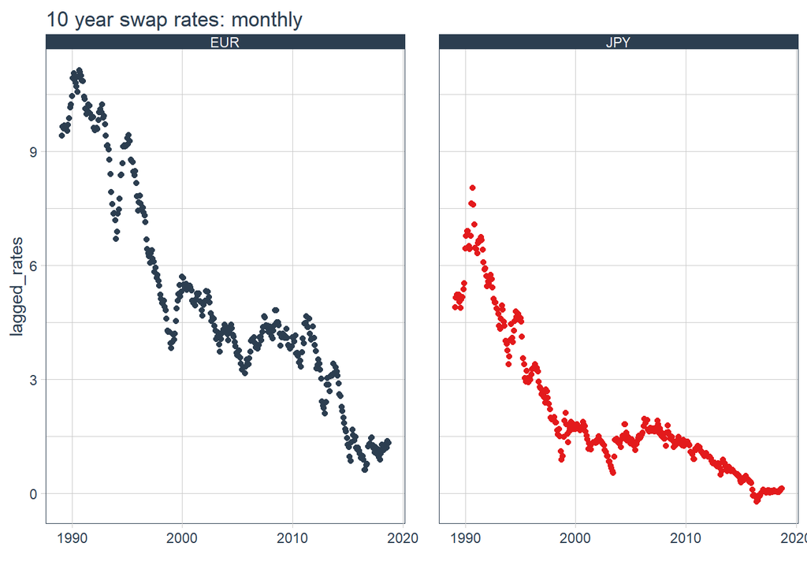

```r
date <- as.Date(data_all[,1]) %>% rep(2)
currency <- rep(c("JPY", "EUR"), each = length(data_all[, 1]))
rates <- c(data_all[, 2], data_all[, 3])
rates <- tibble(date = date, rates = rates, currency = currency) %>%
  group_by(currency)
date_lagged <- as.Date(data_all[-1,1]) %>% rep(2)
currency <- rep(c("JPY", "EUR"), each = length(data_all[-1, 1]))
lagged_rates <- c(data_all[2:length(data_all[,2]), 2], data_all[2:length(data_all[,3]), 3])
diff_rates <- c(diff(data_all[, 2]), diff(data_all[, 3]))
diff_rates <- tibble(date = date_lagged, diff_rates = diff_rates, lagged_rates = lagged_rates, currency = currency) %>%
  group_by(currency)
#rates <- tibble(date = as.Date(data_all[,1]), rates = data_all[,2], currency = rep("JPY", length(data_all[,2])))

#str(rates)

diff_rates %>%
    ggplot(aes(x = date, y = lagged_rates, color = currency)) +
    geom_point() +
    labs(title = "10 year swap rates: monthly", x = "") +
    facet_wrap(~ currency) +
    scale_color_tq() +
    theme_tq() +
    theme(legend.position="none")
```

EUR rates and JPY rates have downward trends. The JPY rates fall below zero lately. At least some sort of trend should be included in the rate model.

### Differences

Let’s try to pull the trend out by differencing the data with first differences of the rates.

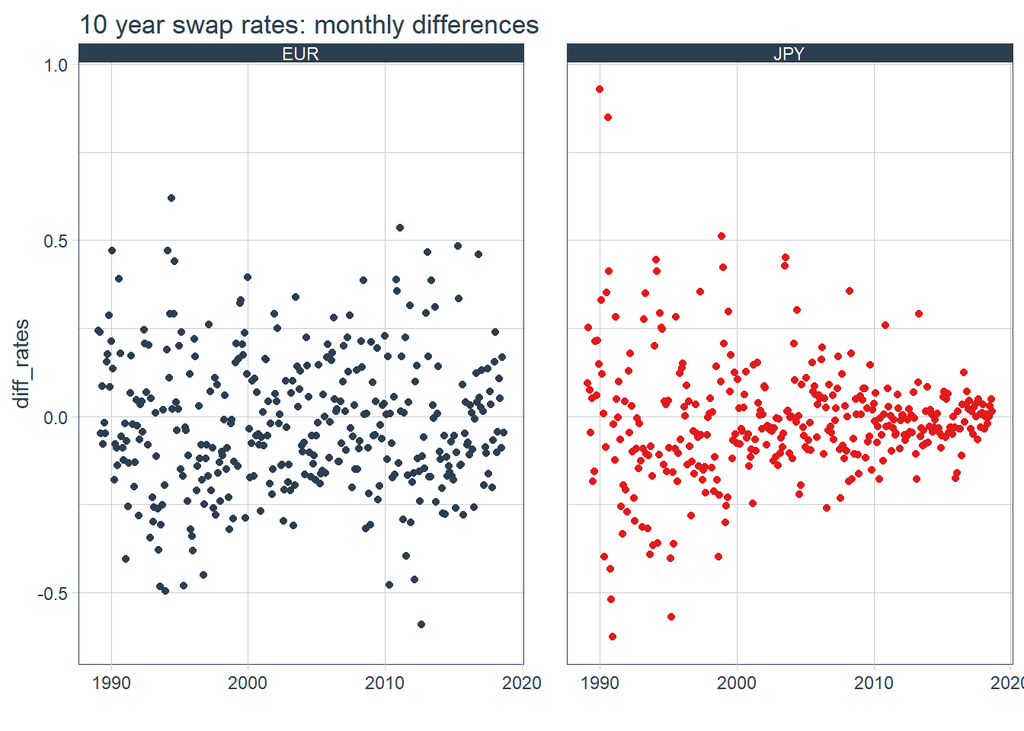

```r
date_lagged <- as.Date(data_all[-1,1]) %>% rep(2)
currency <- rep(c("JPY", "EUR"), each = length(data_all[-1, 1]))
lagged_rates <- c(data_all[2:length(data_all[,2]), 2], data_all[2:length(data_all[,3]), 3])
diff_rates <- c(diff(data_all[, 2]), diff(data_all[, 3]))
diff_rates_1 <- tibble(date = date_lagged, diff_rates = diff_rates, lagged_rates = lagged_rates, currency = currency) %>%
  group_by(currency)
#rates <- tibble(date = as.Date(data_all[,1]), rates = data_all[,2], currency = rep("JPY", length(data_all[,2])))

#str(rates)
diff_rates_1 %>%
    ggplot(aes(x = date, y = diff_rates, color = currency)) +
    geom_point() +
    labs(title = "10 year swap rates: monthly differences", x = "") +
    facet_wrap(~ currency) +
    scale_color_tq() +
    theme_tq() +
    theme(legend.position="none")
```

EUR rates exhibit a fairly consistent movement of rate differences around zero, with a few outliers. JPY rates seem to have two behaviors: one is very scattered up to 2010, the other more concentrated as rates approach zero and become negative after 2010. Given the way JPY behaves, perhaps a sample that reaches into the beginnning of 2010 will show us a consistent trend. This will help us also understand the longer-run movements as rates begin to lift themselves up from the extremely low, and sometimes negative, levels lately.

Let’s see if there is any relationship between the current and past months’ rates as well. Significance in auto-correlation plots shows up as a vertical ine that exceeds the blue dashed 95% confidence interval. Auto-correlations of raw rates show very strong reliance of current months’ rates on the not so recent past months of rates.

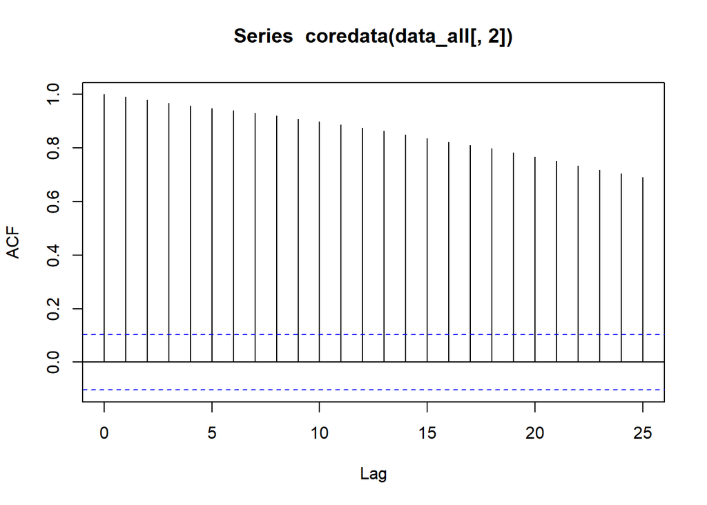

```r
acf(coredata(data_all[,2]), title = "Monthly JPY 10 rates")
```

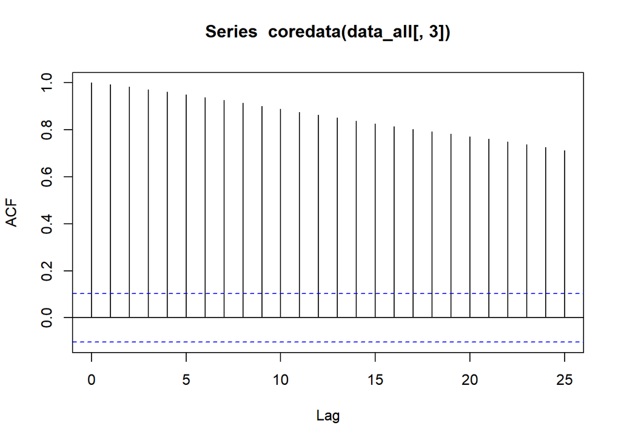

```r
acf(coredata(data_all[,3]), title = "Monthly EUR 10 rates")
```

First differencing of the rates shows a very different picture.

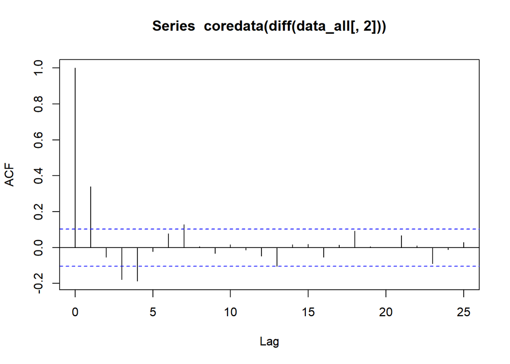

```r
acf(coredata(diff(data_all[,2])), title = "First differences: JPY 10 year rates")
```

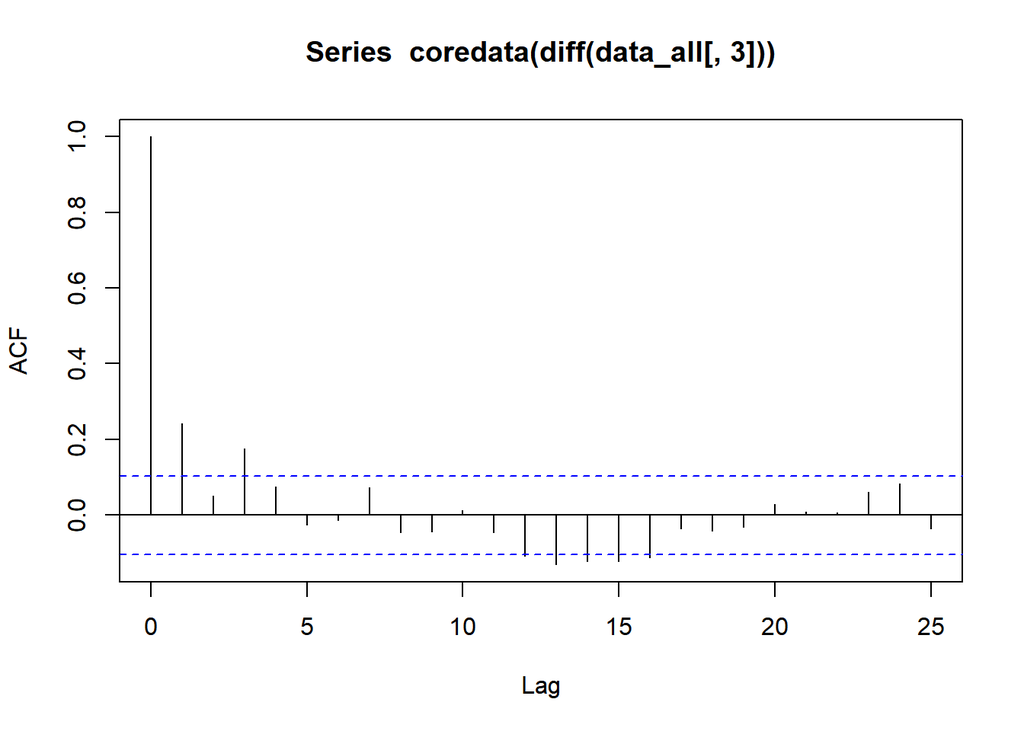

```r
acf(coredata(diff(data_all[,3])), title = "First differences: EUR 10 year rates")
```

Both JPY and EUR rates exhibit a one-month lagged significant relationship to the first differenced rates.

The rate model should then consider differences of rates as they depend on the lagged one-month rate.

### Volatility

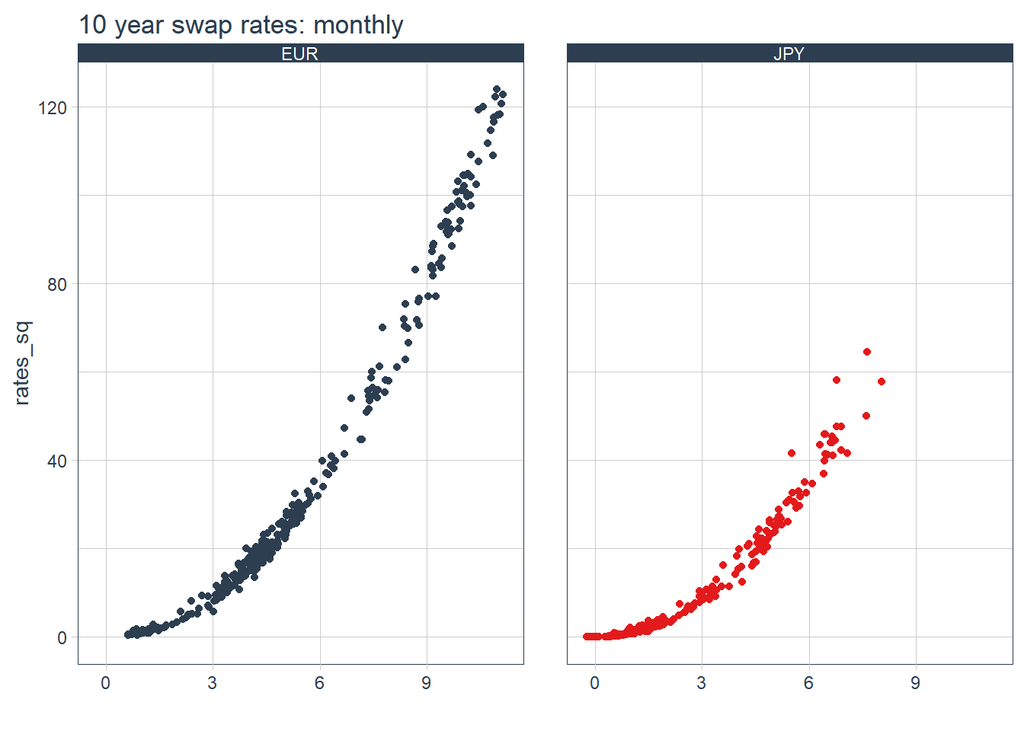

```r
n <- length(data_all[,1])
date_lagged <- as.Date(data_all[-1,1]) %>% rep(2)
currency_lagged <- rep(c("JPY", "EUR"), each = length(data_all[-1, 1]))
lagged_rates <- c(data_all[1:(n-1), 2], data_all[1:(n-1), 3])
diff_rates <- c(diff(data_all[, 2]), diff(data_all[, 3]))
rates_sq <- c(data_all[2:n, 2]^2, data_all[2:n, 3]^2)
diff_rates_vol <- tibble(date = date_lagged, diff_rates = diff_rates, rates_sq = rates_sq, lagged_rates = lagged_rates, currency = currency_lagged) %>%
  group_by(currency)
diff_rates_vol %>%
    ggplot(aes(x = lagged_rates, y = rates_sq, color = currency)) +
    geom_point() +
    labs(title = "10 year swap rates: monthly", x = "") +
    facet_wrap(~ currency) +
    scale_color_tq() +
    theme_tq() +
    theme(legend.position="none")
```

## Build we must

For our last trick let’s create, almost out of thin air, but air nonetheless, the sample mean and standard deviation distributions of JPY and EUR 10-year swap rates from the historical record. This will allow us to bound our simulations should that become necessary. Here are the many calculations needed.

```r
# get the data
#data_all <- read.csv("data/jpy-eur-10-rates.csv")
#r_JPY <-  data_all[1:276,2]
#r_EUR <- data_all[1:276,3]

# expected shortfall for a later discussion
ES_calc <- function(data, prob){
  data <- as.matrix(data)
  return(mean(data[data > quantile(data, prob),]))
}

# we embed this resample path into a much larger sampling routine
bootstrap_resample <- function (data, n_sample) {
  sample(data, n_sample, replace=TRUE)
}
# build this routine to get several bootstrapped (replacement) paths of sampled means and standard deviations
mean_sd_sampled <- function(data, n_sample, data_2 = NULL){
  # simple one=path bootstrap function
  bootstrap_resample <- function (data, n_sample) {
  sample(data, n_sample, replace=TRUE)
  }
  # use bootstrap_resample with the mean and sd, then replicate a lot of times
  replicate_mean <- replicate(1000, mean(bootstrap_resample (data, n_sample)))
  replicate_sd <- replicate(1000, sd(bootstrap_resample (data, n_sample)))
  # report quantiles
  results <- list(
    mean_simulation = replicate_mean,
    q_m_0.025 = quantile(replicate_mean, 0.025),
    q_m_0.500 = quantile(replicate_mean, 0.500),
    q_m_0.975 = quantile(replicate_mean, 0.975),
    sd_simulation = replicate_sd,
    q_sd_0.025 = quantile(replicate_sd, 0.025),
    q_sd_0.500 = quantile(replicate_sd, 0.500),
    q_sd_0.975 = quantile(replicate_sd, 0.975)
  )
  return(results)
}
corr_sampled <- function(data_1, data_2, n_sample){
  # simple one=path bootstrap function
  bootstrap_resample <- function (data, n_sample) {
  sample(data, n_sample, replace=TRUE)
  }
  # use bootstrap_resample with the mean and sd, then replicate a lot of times
  replicate_corr <- replicate(1000, cor(bootstrap_resample(data_1, n_sample), bootstrap_resample (data_2, n_sample)))
  # report quantiles
  results <- list(
    corr_simulation = replicate_corr,
    q_corr_0.025 = quantile(replicate_corr, 0.025),
    q_corr_0.500 = quantile(replicate_corr, 0.500),
    q_corr_0.975 = quantile(replicate_corr, 0.975)
  )
  return(results)
}
sampled_JPY <- mean_sd_sampled(r_JPY, 50)
sampled_EUR <- mean_sd_sampled(r_EUR, 50)
sampled_JPY_EUR <- corr_sampled(r_JPY, r_EUR, 50)

# next build a table of the 95\% confidence interval for means and standard deviations of the two series
# easier to read below
JPY <- sampled_JPY
EUR <- sampled_EUR
JPY_EUR <- sampled_JPY_EUR
header <- c("Q(2.5%)", "Q(50%)", "Q(97.5%)")
margin <- c("mean JPY", "sd JPY", "mean EUR", "sd EUR", "corr JPY-EUR")
row_1 <- c(JPY$q_m_0.025, JPY$q_m_0.500, JPY$q_m_0.975)
row_2 <- c(JPY$q_sd_0.025, JPY$q_sd_0.500, JPY$q_sd_0.975)
row_3 <- c(EUR$q_m_0.025, EUR$q_m_0.500, EUR$q_m_0.975)
row_4 <- c(EUR$q_sd_0.025, EUR$q_sd_0.500, EUR$q_sd_0.975)
row_5 <- c(JPY_EUR$q_corr_0.025, JPY_EUR$q_corr_0.500, JPY_EUR$q_corr_0.975)
table_5 <- rbind(row_1, row_2, row_3, row_4, row_5)
colnames(table_5) <- header
rownames(table_5) <- margin
table_5 %>%
  kable() %>%
    kable_styling(bootstrap_options = c("striped", "hover"), full_width = F)
```

|  | Q(2.5%) | Q(50%) | Q(97.5%) |
| --- | --- | --- | --- |
| mean JPY | 2.1827 | 2.6748 | 3.1696 |
| sd JPY | 1.4165 | 1.8014 | 2.1369 |
| mean EUR | 5.4205 | 6.0726 | 6.7807 |
| sd EUR | 1.9924 | 2.4122 | 2.6943 |
| corr JPY-EUR | -0.2658 | 0.0016 | 0.2887 |

The table gives us the raw ranges of the systematic movement of JPY and EUR rates. Here are some distributions to put a point on all of this work.

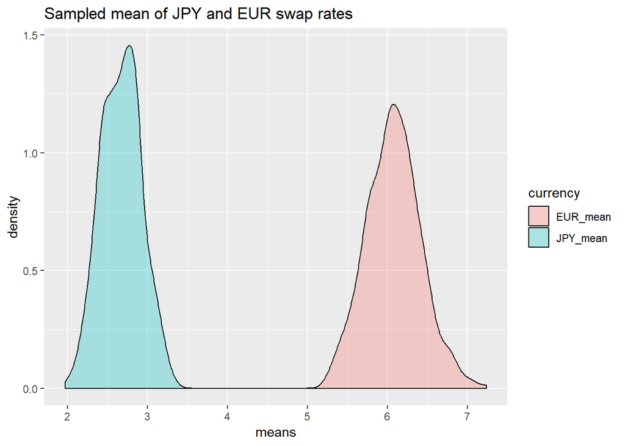

```r
# build tables
n <- length(r_JPY)
raw_rates <- c(r_JPY, r_EUR)
raw_currency <- rep(c("JPY", "EUR"), each = n)
raw_distr <- tibble(rates = raw_rates, currency = raw_currency)
sim_mean <- c(JPY$mean_simulation, EUR$mean_simulation)
sim_sd <- c(JPY$sd_simulation, EUR$sd_simulation)
n <- length(JPY$mean_simulation)
sim_currency_mean <- rep(c("JPY_mean", "EUR_mean"), each = n)
sim_currency_sd <- rep(c("JPY_sd", "EUR_sd"), each = n)
sim_mean_d <- tibble(means = sim_mean, currency = sim_currency_mean)
sim_sd_d <- tibble(sd = sim_sd, currency = sim_currency_sd)
# build distributions
ggplot(sim_mean_d , aes(x = means, fill = currency)) + geom_density(alpha = .3) + ggtitle("Sampled mean of JPY and EUR swap rates")
```

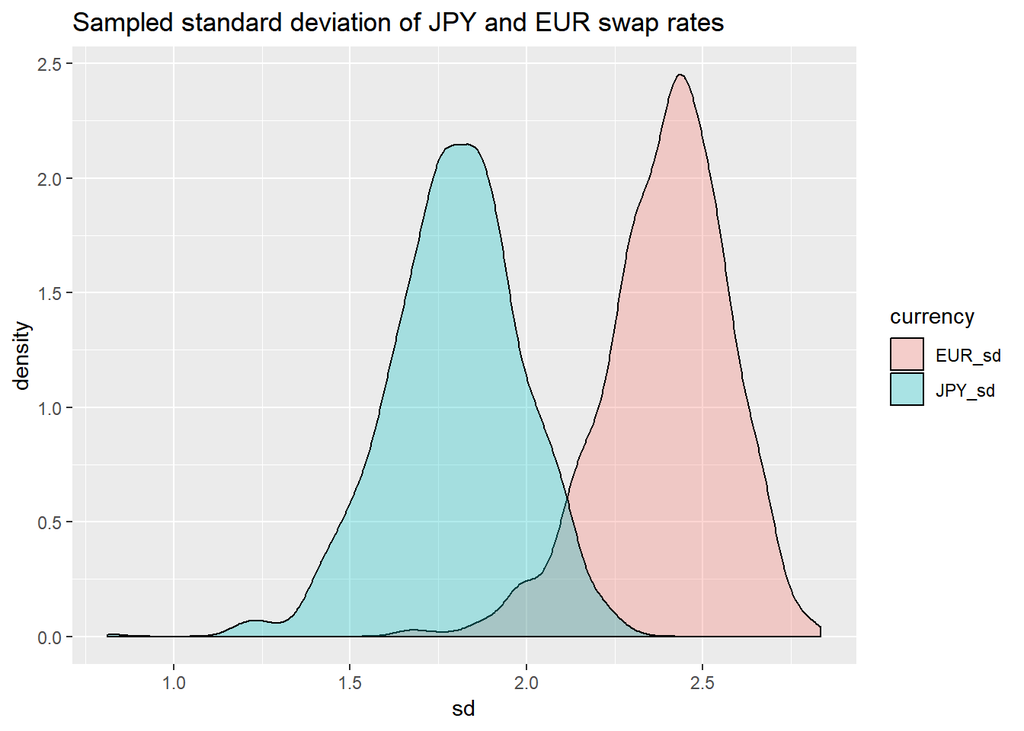

```r
ggplot(sim_sd_d , aes(x = sd, fill = currency)) + geom_density(alpha = .3) + ggtitle("Sampled standard deviation of JPY and EUR swap rates")
```

EUR swap rates clear the JPY rates. Their standard deviations can overlap, and thus we might see some leakage of volatility from one market into the other.

The correlation between the two rates is similarly considered.

## A model is born

In A nut-shell we are looking for a rate model that has:

- Rates that revert to a trend that depends on the lagged rate.
- Volatility that is increasing in the rate in an exponential fashion.

Chan, Karolyi, Longstaff, Sanders (1994) minted a mean-reverting model of interest rate changes with non-constant volatility that fits our preliminary observations. This sort of model explains much of the shape of yield curves and is often in use as a model of the short-term interest rate. We stretch that idea here into a 10-year ensemble of rates.

In continuous time the following stochastic differential equation specifies paths of interest rates $r$,

$$dr_t = \alpha(\theta - r_t)dt + \lambda r_t^{\gamma} dW_t$$

where $\alpha$ determines the speed of reversion to the long-run mean $\theta$ of changes in interest $r$ for small time increments $dt$, and $\lambda$ is a constant level of rate variance with $\gamma$ a constant elasticity of variance dependent on interest rate $r$ scaling a change $dW_t$ standard Wiener (Brownian) process with mean zero and variance $t$. We then discretize this model using unit time intervals.

$$r_{t+1} - r_{t} = \alpha (\theta - r_t) + \varepsilon_{t+1}$$
The second equation specifies the evolution of the volatility of rates measured by the variance of the error term $\varepsilon_{t+1}$.
$$E[\varepsilon_{t+1}] = 0, \,\,E[\varepsilon_{t+1}^2] = \lambda r_t^{\gamma}$$

The rate volatility depends on the previous rate $r_t$ through an average level of rate volatility captured by $\lambda$, If $\gamma = 0$ then rate variance is constant. The percentage rate of change of variance with respect to the percentage change in the lagged-rate is a constant $\gamma$ and thus the name constant elasticity of variance model.

## Parameter estimation

We estimate the CEV model in three stages:

1. The first stage calculates the parameters of the mean reverting trend for each currency’s rate.
2. The second stage computes the parameters of the stochastic volatility for each currency’s rate.
3. The third and final stage fine tunes the first stage mean-reversion estimates using the fitted residuals from the second stage as weights on the first stage to build in the constant volatility aspects of the trend.

Here is a function to accomplish the three estimation stages.

```r
cev_est <- function(data){
  # estimates a Chan, Karolyi, Longstaff, Sanders constant elasticity of variance model
  # of the short-term interest rate:
  # dr = alpha*(theta - r)dt + sigma^gamma * r^2 * dz
  # using a forward Euler difference approximation
  # Setup the data: data is a numeric vector of one interest rate series, already
  # clean and ready for use. Note: this model is very sketchy for negative
  # and near zero interest rates.
              r <- data
              n <- length(r)
              r_1 <-  stats::lag(r)[-n] # in case tidyverse conflicts
              delta_r <-  diff(r)
  # estimate first stage mean reversion trend
              nlmod_mrv <-  nls(delta_r ~ a * (theta-r_1),
                 start = list(theta = 2, a = 0.01),
                 control = list(maxiter = 100))
  # estimate second stage volatility component
              res_sq <-  as.vector(residuals(nlmod_mrv)^2)
              nlmod_res <- nls(res_sq ~  lambda*r_1^gamma,
                 start = list(lambda = 0.1, gamma = 1/2),
                 control = list(maxiter = 100))
  # estimate third stage weighted mean reversion trend
              nlmod_res_fit <- fitted(nlmod_res)
              nlmod_wgt <-  nls(delta_r ~ a * (theta-r_1),
                 start = list(theta = 2, a = 0.01),
                 control = list(maxiter = 100),
                 weights=1/nlmod_res_fit)
  # return results
              results <- list(
                parm_mrv = summary(nlmod_wgt),
                parm_vol = summary(nlmod_res)
              )
              return(results)
}
```

Using the first 250 months of data (remember we saw that 2010 seems a likely regime change in rates), we estimate trend and volatility for the JPY swap rates.

```r
cev_JPY <- cev_est(data_all[1:250, 2])
cev_JPY$parm_mrv
```

```
##
## Formula: delta_r ~ a * (theta - r_1)
##
## Parameters:
##       Estimate Std. Error t value Pr(>|t|)
## theta  1.98478    0.52940    3.75  0.00022 ***
## a      0.02060    0.00968    2.13  0.03432 *
## ---
## Signif. codes:  0 '***' 0.001 '**' 0.01 '*' 0.05 '.' 0.1 ' ' 1
##
## Residual standard error: 1.25 on 247 degrees of freedom
##
## Number of iterations to convergence: 2
## Achieved convergence tolerance: 0.00000000059
```

```r
cev_JPY$parm_vol
```

```
##
## Formula: res_sq ~ lambda * r_1^gamma
##
## Parameters:
##        Estimate Std. Error t value Pr(>|t|)
## lambda  0.00765    0.00415    1.84    0.067 .
## gamma   1.39017    0.32002    4.34  0.00002 ***
## ---
## Signif. codes:  0 '***' 0.001 '**' 0.01 '*' 0.05 '.' 0.1 ' ' 1
##
## Residual standard error: 0.0873 on 247 degrees of freedom
##
## Number of iterations to convergence: 9
## Achieved convergence tolerance: 0.00000577
```

Nearly all the JPY rate parameters are significant, especially if we can accept a 7-10% significance level that we might be wrong that the parameters are significant.

Next we estimate trend and volatility parameters for the EUR swap rates.

```r
cev_EUR <- cev_est(data_all[1:250, 3])
cev_EUR$parm_mrv
```

```
##
## Formula: delta_r ~ a * (theta - r_1)
##
## Parameters:
##       Estimate Std. Error t value Pr(>|t|)
## theta  2.21887    4.29124    0.52     0.61
## a      0.00517    0.00521    0.99     0.32
##
## Residual standard error: 0.998 on 247 degrees of freedom
##
## Number of iterations to convergence: 2
## Achieved convergence tolerance: 0.00000000086
```

```r
cev_EUR$parm_vol
```

```
##
## Formula: res_sq ~ lambda * r_1^gamma
##
## Parameters:
##        Estimate Std. Error t value Pr(>|t|)
## lambda  0.01270    0.00597    2.13    0.034 *
## gamma   0.57869    0.23831    2.43    0.016 *
## ---
## Signif. codes:  0 '***' 0.001 '**' 0.01 '*' 0.05 '.' 0.1 ' ' 1
##
## Residual standard error: 0.0517 on 247 degrees of freedom
##
## Number of iterations to convergence: 6
## Achieved convergence tolerance: 0.0000017
```

Volatility clearly carries the model of EUR swap rates with a near-zero trend in rate differences.

## Simulating rates

We unpack the parameters for use in a simulation.

```r
# J is JPY and E is EUR
alpha_J <- cev_JPY$parm_mrv$coefficients[2]
theta_J <- cev_JPY$parm_mrv$coefficients[1]
lambda_J <- cev_JPY$parm_vol$coefficients[1]
gamma_J <- cev_JPY$parm_vol$coefficients[2]
alpha_E <- cev_EUR$parm_mrv$coefficients[2]
theta_E <- cev_EUR$parm_mrv$coefficients[1]
lambda_E <- cev_EUR$parm_vol$coefficients[1]
gamma_E<- cev_EUR$parm_vol$coefficients[2]
# For example one simulation path
r_0 <- 2.0
alpha <- 0.01
theta <- 2.0
lambda <- 0.02
gamma <- 1.5
n <-  10#n_sim # lots of trials
z <- rnorm(n) # sample standard normal distribution variates
e <-  z # store variates
r <-  rep(r_0, n) # store again in a different place
sig2 <-  z^2 # create initial volatility series
set.seed("1012")
for (t in 2:n) {
    # Because of lag start at second date
    e[t] <- sqrt(sig2[t])*z[t]                             # 1. e is conditional on sig
    r[t] <-  r[t-1] + alpha*(theta - r[t-1]) + e[t] # 2. generate returns
    sig2[t+1] <- (lambda*r[t]^gamma)              # 3. generate new sigma(r,t) to feed 1.
}
quantile(r, 0.025)
```

```
##  2.5%
## 1.824
```

```r
quantile(r, 0.5)
```

```
## 50%
##   2
```

```r
quantile(r, 0.975)
```

```
## 97.5%
## 2.294
```

```r
# wrap a functiona round it all
rate_sim <- function(r_0, alpha, theta, lambda, gamma, years){
  # to do: time steps, years, time to maturity surface
  z <- rnorm(years) # sample standard normal distribution variates
  e <-  z # store variates
  r <-  rep(r_0, years) # store again in a different place
  sig2 <-  z^2 # create initial volatility series
  for (t in 2:years) {
    # Because of lag start at second date
    e[t] <- sqrt(sig2[t])*z[t]                             # 1. e is conditional on sig
    r[t] <-  r[t-1] + alpha*(theta - r[t-1]) + e[t] # 2. generate returns
    sig2[t+1] <- lambda*abs(r[t])^gamma              # 3. generate new sigma(r,t) to feed 1.
  }
  results <- list(
    e_t = e,
    r_t = r,
    sig = sqrt(sig2)
  )
  return(results)
}
# simulate n_sim 10 year paths
n_sim <- 1000
years <- 10
r_0_J <- median(r_JPY)
r_sim_J <- matrix(0, nrow = n_sim, ncol = years)
for (i in 1:n_sim){
  r_sim_J[i,] <- rate_sim(r_0_J, alpha_J, theta_J, lambda_J, gamma_J, 10)$r_t
  }
r_sim_E <- matrix(0, nrow = n_sim, ncol = years)
for (i in 1:n_sim){
  r_sim_E[i,] <- rate_sim(1, alpha_E, theta_E, lambda_E, gamma_E, 10)$r_t
}
```

## VISUALIZE?? (until morale improves!)

Here is a routine to begin a visualization of the simulations of the 10 year rates over a 10 year period.

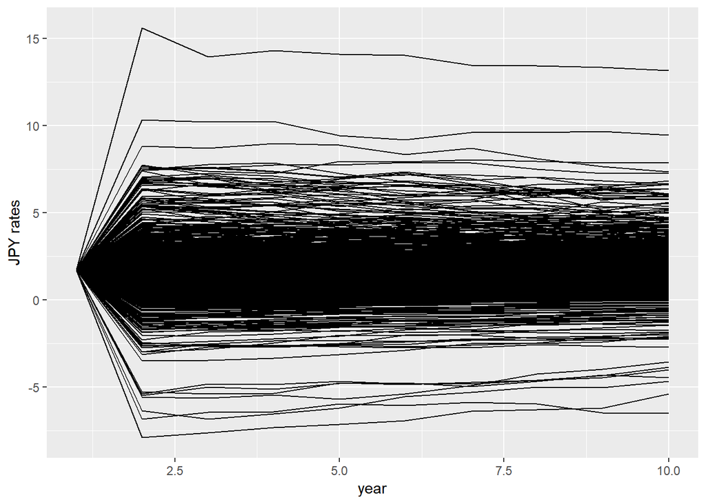

```r
library(reshape2)
r_sim_J_melt <- r_sim_J %>%
  t() %>%
  melt() %>%
  group_by(Var2)

ggplot(r_sim_J_melt, aes(x= Var1, y=value, group = Var2)) + geom_line() + xlab("year") + ylab("JPY rates")
```

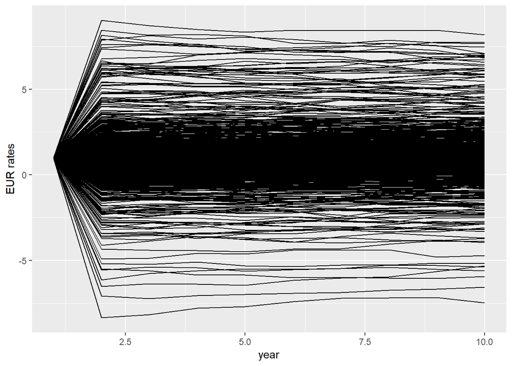

```r
r_sim_E_melt <- r_sim_E %>%
  t() %>%
  melt() %>%
  group_by(Var2)

ggplot(r_sim_E_melt, aes(x= Var1, y=value, group = Var2)) + geom_line() + xlab("year") + ylab("EUR rates")
```

A better plot might be to pick out quantiles of the simulations.

## A swap meet

Here is some data and the calculations for the net present value of a principal-only JPY to EUR asset swap in 10 years.

```r
n <- 10
notional_EUR <- 10
#JPY_fwd <- 150
JPY_spot <- 135 #JPY/EUR
JPY_fwd <- JPY_spot * (1+r_sim_J[,10]/100)^n / (1+r_sim_E[,10]/100)^n
pv_EUR <- notional_EUR / (1+r_sim_E[,10]/100)^n
pv_JPY <- notional_EUR * median(JPY_fwd) / (1+r_sim_J[,10]/100)^n # not convolved!
npv <- pv_EUR - pv_JPY / JPY_spot
```

Let’s exchange EUR10 for JPY in 10 years. In arbitrage, the interest rate parity implies

$$_0F_{10}^{JPY/EUR} = S_0^{JPY/EUR} \frac{(1+r_{JPY})^{10}}{(1+r_{EUR})^{10}}$$
where we solve for the date $0$ forward JPY/EUR rate at year 10, $_0F_{10}^{JPY/EUR}$. In this arbitrage the *domestic* currency is *JPY* and the *foreign* currency is *EUR*.

Remember the IRP no-arbitrage transaction?

## Swap metrics (AKA results!)

Using the interest rate simulations for 10 year JPY and EUR swaps we calculate the median present value of the 10 as EUR9.0428. With the median JPY forward rate of JPY144.884/EUR, the median present value of the equivalent JPY principal of JPY1448.8398 is JPY1223.6024.

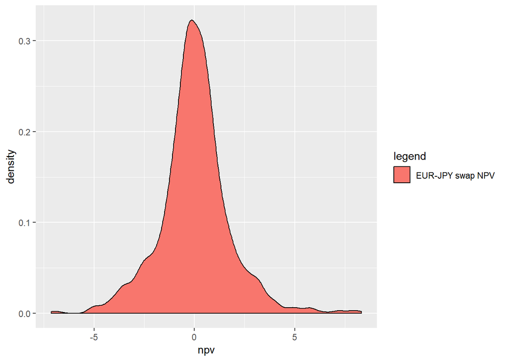

```r
npv_df <- tibble(npv = npv, legend = rep("EUR-JPY swap NPV"), length(npv) )
ggplot(npv_df, aes(x = npv, fill = legend)) + geom_density() + xlim(quantile(npv, 0.005), quantile(npv, 1-0.005))
```

Comparing both the EUR and JPY legs at present values in EUR yields a slightly negative median net present value of EUR0, in favor of the JPY leg. About 95% of the potential npv realizations occur between EUR-3.744 and EUR4.0033.

## References

FRED